# Python for Data Science Assignment 1

**Submitted by: L**

The following is the list of datasets use for this assignment

- https://data.gov.sg/dataset/public-transport-utilisation-average-public-transport-ridership
- https://data.gov.sg/dataset/public-transport-utilisation-average-trip-distance
- https://data.gov.sg/dataset/monthly-taxi-population-by-company

```python
# turn off warning and import all libraries
import warnings
import numpy as np
import matplotlib.pyplot as plt
%matplotlib inline
warnings.filterwarnings('ignore')
```

# Data Analysis

## Public Transport Utilization - Ridership

https://data.gov.sg/dataset/public-transport-utilisation-average-public-transport-ridership

```python
ptridership = np.genfromtxt(
    "data/public-transport-utilisation-average-public-transport-ridership.csv",
    dtype=["datetime64[Y]","U100",int],
    delimiter=",",
    names=True)
ptridership[:10]
```

```
array([('1995', 'MRT',  740000), ('1995', 'LRT',       0),
       ('1995', 'Bus', 3009000), ('1995', 'Taxi',       0),
       ('1996', 'MRT',  850000), ('1996', 'LRT',       0),
       ('1996', 'Bus', 3118000), ('1996', 'Taxi',       0),
       ('1997', 'MRT',  911000), ('1997', 'LRT',       0)],
      dtype=[('year', '<M8[Y]'), ('type_of_public_transport', '<U100'), ('average_ridership', '<i8')])
```

```python
years = np.unique(ptridership["year"])
years = years.astype(object)
years
```

```
array([datetime.date(1995, 1, 1), datetime.date(1996, 1, 1),
       datetime.date(1997, 1, 1), datetime.date(1998, 1, 1),
       datetime.date(1999, 1, 1), datetime.date(2000, 1, 1),
       datetime.date(2001, 1, 1), datetime.date(2002, 1, 1),
       datetime.date(2003, 1, 1), datetime.date(2004, 1, 1),
       datetime.date(2005, 1, 1), datetime.date(2006, 1, 1),
       datetime.date(2007, 1, 1), datetime.date(2008, 1, 1),
       datetime.date(2009, 1, 1), datetime.date(2010, 1, 1),
       datetime.date(2011, 1, 1), datetime.date(2012, 1, 1),
       datetime.date(2013, 1, 1), datetime.date(2014, 1, 1),
       datetime.date(2015, 1, 1), datetime.date(2016, 1, 1)], dtype=object)
```

```python
modes = np.unique(ptridership["type_of_public_transport"])
modes
```

```
array(['Bus', 'LRT', 'MRT', 'Taxi'], dtype='<U100')
```

```python
bus = ptridership[ptridership["type_of_public_transport"]=="Bus"]["average_ridership"]
bus
```

```
array([3009000, 3118000, 3116000, 3121000, 3213000, 3251000, 3281000,
       3197000, 2992000, 2805000, 2779000, 2833000, 2932000, 3087000,
       3047000, 3199000, 3385000, 3481000, 3601000, 3751000, 3891000,
       3939000])
```

```python
lrt = ptridership[ptridership["type_of_public_transport"]=="LRT"]["average_ridership"]
lrt
```

```
array([     0,      0,      0,      0,  27000,  39000,  41000,  39000,
        50000,  55000,  69000,  74000,  79000,  88000,  90000, 100000,
       111000, 124000, 132000, 137000, 153000, 180000])
```

```python
mrt = ptridership[ptridership["type_of_public_transport"]=="MRT"]["average_ridership"]
mrt
```

```
array([ 740000,  850000,  911000,  946000,  986000, 1047000, 1071000,
       1081000, 1171000, 1270000, 1321000, 1408000, 1527000, 1698000,
       1782000, 2069000, 2295000, 2525000, 2623000, 2762000, 2879000,
       3095000])
```

```python
taxi = ptridership[ptridership["type_of_public_transport"]=="Taxi"]["average_ridership"]
taxi
```

```
array([      0,       0,       0,       0,       0,       0,  880000,
        839000,  805000,  852000,  980000,  946000,  944000,  909000,
        860000,  912000,  933000,  967000,  967000, 1020000, 1010000,
        954000])
```

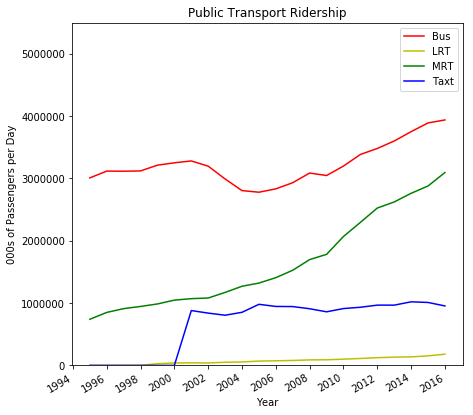

```python
import matplotlib.dates as mdates
years_loc = mdates.YearLocator(2)   # every 2 year
years_fmt = mdates.DateFormatter('%Y')
#months_loc = mdates.MonthLocator()  # every month

fig = plt.figure(figsize=(7, 7))
ax = plt.axes()
plt.plot(years,bus,"r-")
plt.plot(years,lrt,"y-")
plt.plot(years,mrt,"g-")
plt.plot(years,taxi,"b-")

# Set Xticks
ax.xaxis.set_major_locator(years_loc)
ax.xaxis.set_major_formatter(years_fmt)
#ax.xaxis.set_minor_locator(months_loc)

plt.title("Public Transport Ridership")
plt.xlabel("Year")
plt.ylabel("000s of Passengers per Day")
plt.legend(['Bus','LRT','MRT','Taxt'])
plt.ylim(0,5500000)
fig.autofmt_xdate()
plt.show()
```

The line graph above show that the most popular mode of transport is Bus

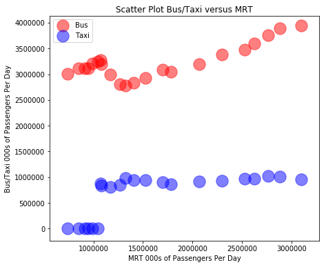

```python
plt.figure(figsize=(7, 6))
plt.scatter(mrt,bus,c='red',s=300,alpha=0.5)
plt.scatter(mrt,taxi,c='blue',s=300,alpha=0.5)
plt.title("Scatter Plot Bus/Taxi versus MRT")
#plt.ylim(0,4500000)
plt.xlabel("MRT 000s of Passengers Per Day")
plt.ylabel("Bus/Taxi 000s of Passengers Per Day")
plt.legend(['Bus','Taxi'])
plt.show()
```

The purpose for the scatter plot above shows relationship between the number of bus passengers and the number of MRT passengers. There seems to be no relationship as the number of taxi passengers is a flat line relative to number of MRT passengers.

## Public Transport Utilization - Average Trip Distance

https://data.gov.sg/dataset/public-transport-utilisation-average-trip-distance

```python
ptrip = np.genfromtxt("data/public-transport-utilisation-average-trip-distance.csv",
                      dtype=(int,"U100",float),
                      delimiter=",",
                      names=True)
ptrip.dtype.names
```

```
('year', 'mode', 'ave_distance_per_trip')
```

```python
years = np.unique(ptrip["year"])
years
```

```
array([2004, 2005, 2006, 2007, 2008, 2009, 2010, 2011, 2012, 2013, 2014])
```

```python
modes = np.unique(ptrip["mode"])
modes
```

```
array(['Bus', 'LRT', 'MRT', 'Taxi'], dtype='<U100')
```

```python
distances = ptrip["ave_distance_per_trip"]
distances
```

```
array([11.5,  0. ,  5.2,  8.5, 11.5,  0. ,  5.4,  8.8, 11.3,  0. ,  5.3,
        9.1, 11.2,  0. ,  5.3,  9.7, 11.2,  2.1,  5.3,  9. , 10.8,  2.1,
        5.1,  9. , 10.3,  2.1,  4.8,  9.3, 10. ,  2. ,  4.5,  9.6,  9.6,
        1. ,  4.4,  9.7,  9.5,  2. ,  4.3,  9.8,  9.2,  2. ,  4.3, 10. ])
```

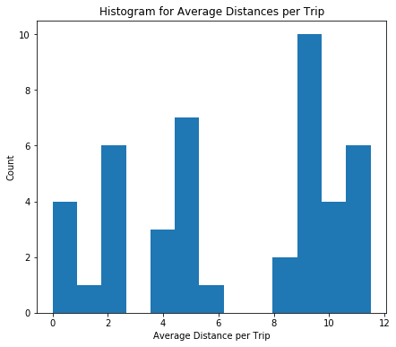

```python
plt.figure(figsize=(7, 6))
plt.hist(distances, bins=13)
plt.title("Histogram for Average Distances per Trip")
plt.xlabel("Average Distance per Trip")
plt.ylabel("Count")
plt.show()
```

The histogram show that there are broadly 3 types of journeys

- Short ones: less than 2 km.
- Medium ones: around 5km
- And long ones: more than 8 km

```python
distancesbus = ptrip[ptrip["mode"]=="Bus"]["ave_distance_per_trip"]
distancesbus
```

```
array([5.2, 5.4, 5.3, 5.3, 5.3, 5.1, 4.8, 4.5, 4.4, 4.3, 4.3])
```

```python
distanceslrt = ptrip[ptrip["mode"]=="LRT"]["ave_distance_per_trip"]
distanceslrt
```

```
array([0. , 0. , 0. , 0. , 2.1, 2.1, 2.1, 2. , 1. , 2. , 2. ])
```

```python
distancesmrt = ptrip[ptrip["mode"]=="MRT"]["ave_distance_per_trip"]
distancesmrt
```

```
array([11.5, 11.5, 11.3, 11.2, 11.2, 10.8, 10.3, 10. ,  9.6,  9.5,  9.2])
```

```python
distancestaxi = ptrip[ptrip["mode"]=="Taxi"]["ave_distance_per_trip"]
distancestaxi
```

```
array([ 8.5,  8.8,  9.1,  9.7,  9. ,  9. ,  9.3,  9.6,  9.7,  9.8, 10. ])
```

```python
data_to_plot = [distancesbus,distanceslrt,distancesmrt,distancestaxi]
```

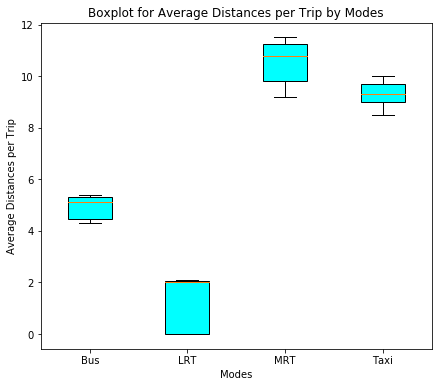

```python
plt.figure(figsize=(7, 6))
bp = plt.boxplot(data_to_plot,labels=["Bus","LRT","MRT","Taxi"],patch_artist=True)
for patch in bp["boxes"]:
    patch.set(facecolor="cyan")
plt.title("Boxplot for Average Distances per Trip by Modes")
plt.xlabel("Modes")
plt.ylabel("Average Distances per Trip")
plt.show()
```

The boxplot above show that the journey length is dependent on mode

- Long journeys are mostly on MRT or Taxi
- Medium journeys are by Bus
- short journeys are by LRT

## Monthly Taxi Population by Company

https://data.gov.sg/dataset/monthly-taxi-population-by-company

```python
taxipop = np.genfromtxt("data/public-transport-capacity-monthly-taxi-population.csv",
                      dtype=("datetime64[Y]","U100",int),
                      delimiter=",",
                      names=True)
taxipop.dtype
```

```
dtype([('month', '<M8[Y]'), ('company', '<U100'), ('taxi_fleet', '<i8')])
```

```python
taxipop[:5]
```

```
array([('2005', 'Comfort', 9952), ('2005', 'CityCab', 4965),
       ('2005', 'SMRT', 2441), ('2005', 'YTC', 1223),
       ('2005', 'Individual Yellow- Top',  696)],
      dtype=[('month', '<M8[Y]'), ('company', '<U100'), ('taxi_fleet', '<i8')])
```

```python
yearsmonths = np.unique(taxipop['month'])
yearsmonths
```

```
array(['2005', '2006', '2007', '2008', '2009', '2010', '2011', '2012',
       '2013', '2014', '2015', '2016', '2017'], dtype='datetime64[Y]')
```

```python
companies = np.unique(taxipop['company'])
companies
```

```
array(['CityCab', 'Comfort', 'Individual Yellow- Top', 'Premier', 'Prime',
       'SMRT', 'Smart', 'TransCab', 'YTC'], dtype='<U100')
```

```python
# For each of taxi companies, find the average number of taxis
avgs = []
labels = []
for c in companies:
    labels.append(c)
    mu = np.mean(taxipop[taxipop["company"]==c]["taxi_fleet"])
    avgs.append(mu)
```

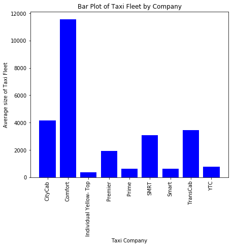

```python
plt.figure(figsize=(7, 6))
bar0 = plt.bar(labels,avgs,color="blue")
plt.title("Bar Plot of Taxi Fleet by Company")
plt.xlabel("Taxi Company")
plt.xticks(rotation='vertical')
plt.ylabel("Average size of Taxi Fleet")
plt.show()
```

The largest taxi companies are:

1. Comfort
2. CityCab
3. TransCab

```python
comforttaxi = taxipop[taxipop["company"]=="Comfort"]
comforttaxi[:5]
```

```
array([('2005', 'Comfort',  9952), ('2005', 'Comfort', 10046),
       ('2005', 'Comfort', 10083), ('2005', 'Comfort', 10133),
       ('2005', 'Comfort', 10145)],
      dtype=[('month', '<M8[Y]'), ('company', '<U100'), ('taxi_fleet', '<i8')])
```

```python
yearsmonths = np.unique(comforttaxi['month'])
yearsmonths = yearsmonths.astype(object)
yearsmonths
```

```
array([datetime.date(2005, 1, 1), datetime.date(2006, 1, 1),
       datetime.date(2007, 1, 1), datetime.date(2008, 1, 1),
       datetime.date(2009, 1, 1), datetime.date(2010, 1, 1),
       datetime.date(2011, 1, 1), datetime.date(2012, 1, 1),
       datetime.date(2013, 1, 1), datetime.date(2014, 1, 1),
       datetime.date(2015, 1, 1), datetime.date(2016, 1, 1),
       datetime.date(2017, 1, 1)], dtype=object)
```

```python
# need to extract the years from the the datetime64 object
x = [i.year  for i in yearsmonths]
x
```

```
[2005, 2006, 2007, 2008, 2009, 2010, 2011, 2012, 2013, 2014, 2015, 2016, 2017]
```

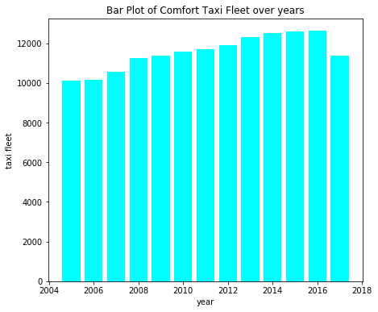

```python
plt.figure(figsize=(7, 6))
data_to_plot = []
for y in yearsmonths:
    data_to_plot.append(np.mean(comforttaxi[comforttaxi["month"] == y]["taxi_fleet"]))

bar1 = plt.bar(x,data_to_plot,color="cyan")
plt.title("Bar Plot of Comfort Taxi Fleet over years")
plt.xlabel("year")
plt.ylabel("taxi fleet")
plt.show()
```

The Bar plot above shows:

- Comfort fleet was growing steadily from 2005 to 2016
- And then the fleet size shrunk in 2017

# Additional examples of subplot 1 row 3 columns

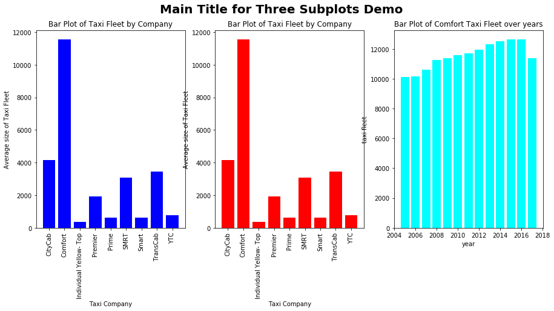

```python
fig, ax = plt.subplots(figsize=(15, 6))
fig.suptitle('Main Title for Three Subplots Demo',fontsize=20,fontweight="bold")

plt.subplot(131)
plt.bar(labels,avgs,color="blue")
plt.title("Bar Plot of Taxi Fleet by Company")
plt.xlabel("Taxi Company")
plt.xticks(rotation='vertical')
plt.ylabel("Average size of Taxi Fleet")

plt.subplot(132)
plt.bar(labels,avgs,color="red")
plt.title("Bar Plot of Taxi Fleet by Company")
plt.xlabel("Taxi Company")
plt.xticks(rotation='vertical')
plt.ylabel("Average size of Taxi Fleet")

plt.subplot(133)
plt.bar(x,data_to_plot,color="cyan")
plt.title("Bar Plot of Comfort Taxi Fleet over years")
plt.xlabel("year")
plt.ylabel("taxi fleet")
plt.show()
```